# suivi de l’activité “grippe” en France

autre source: https://www.grippenet.fr/fr/

Google publie chaque semaine le nombre de fois où quelqu’un a cherhé le mot grippe sur le moteur de recherche google durant la seaine écoulée. Ce nombre est parfaitement corrélé avec l’épidémie de grippe. Google maintient un fichier .csv contenant ces informations hebdomadaires depuis 2002 por une cinquantaine de pays dont leFrance. Principe: on récupère le fichier dans R puis on trace la courbe épidémique en utilisant le package ts (time series)

le ficher comprend un entête de 10 lignes qui ne servent à rien => on les élimine la 11ème ligne (dui devient la 1ère) contient l’intitulé des colonnes. Le tableau se présente comme un tableur: chaque ligne correspond à une semaine, la 1ère ccolonne contient la date (au format aaaa/mm/jj), les colonnes suivantes les pays (1 pays par colonne).

```r
flu<-read.table("http://www.google.org/flutrends/about/data/flu/fr/data.txt",skip=10,header=TRUE,sep=",")
write.csv(flu, file = "flu.csv")
```

on constitue un dataframe de 2 colonnes: date + infos correspondant à la france:

```r
f<-data.frame(flu$Date,flu$France)
```

# suivi de l’activité “grippe” en France

autre source: https://www.grippenet.fr/fr/

Google publie chaque semaine le nombre de fois où quelqu’un a cherché le mot **grippe** sur le moteur de recherche google durant la semaine écoulée. Ce nombre est parfaitement corrélé avec l’épidémie de grippe. Google maintient un fichier .csv contenant ces informations hebdomadaires depuis 2002 por une cinquantaine de pays dont leFrance. Principe: on récupère le fichier dans R puis on trace la courbe épidémique en utilisant le package ts (time series)

le ficher comprend un entête de 10 lignes qui ne servent à rien => on les élimine la 11ème ligne (dui devient la 1ère) contient l’intitulé des colonnes. Le tableau se présente comme un tableur: chaque ligne correspond à une semaine, la 1ère ccolonne contient la date (au format aaaa/mm/jj), les colonnes suivantes les pays (1 pays par colonne).

```r
flu<-read.table("http://www.google.org/flutrends/data.txt",skip=10,header=TRUE,sep=",")
```

on constitue un dataframe de 2 colonnes: date + infos correspondant à la france:

```r
f<-data.frame(flu$Date,flu$France)
# enregistre le dernier fichier consulté
file <- paste0("last_flu_file", Sys.Date(), ".Rda")
save(f, file=file)
```

```r
flutime<-ts(f,start=c(2002,12),frequency=53)
```

on dessine la courbe:

```r
plot(flutime[,2],main="Cas de grippe", ylab="Nombre de cas", xlab="France")
```

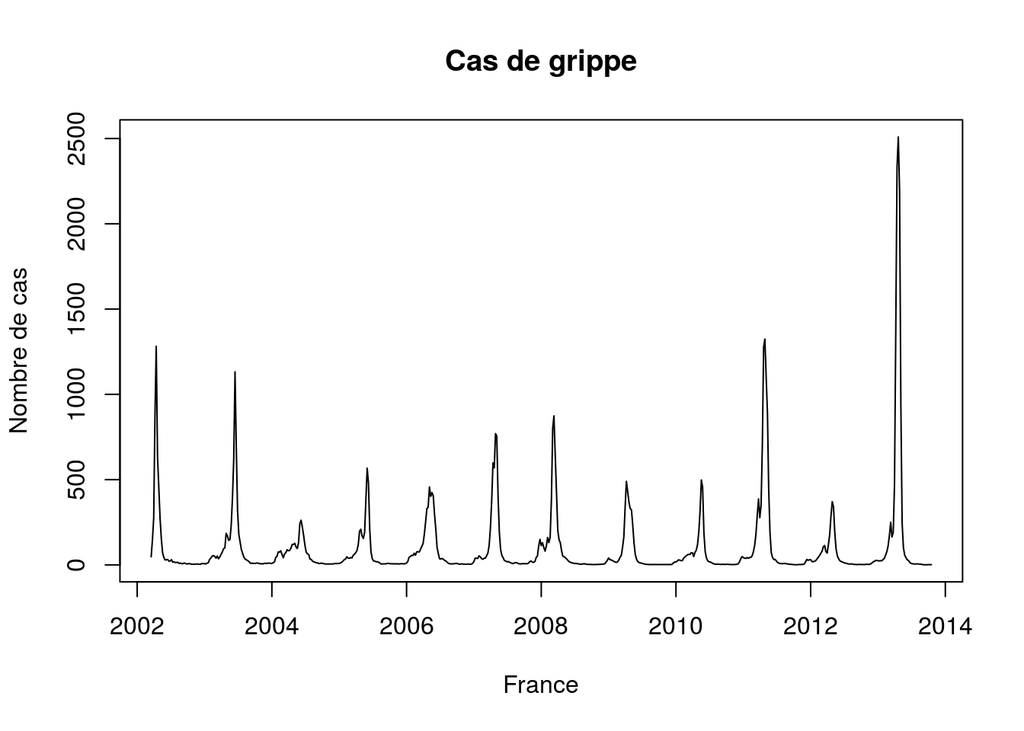

[figure not shown]